# Data Visualization - Binus University

Even Yosua, Handoyo Sjarif, Ridan Lukita, Tomy Tjandra

May 2018

# Getting Started

Hello again! This is the result of our second project. This time, we are interested to analyze about the Balance of Trade for ASEAN countries and then visualize it with the help of ggplot library.

[Balance of Trade (BOT)](https://www.thebalance.com/balance-of-trade-definition-favorable-vs-unfavorable-3306261) is the value of a country’s exports minus its imports. When exports are larger than imports, it’s a trade surplus. Most nations view that as a favorable trade balance. When exports are less than imports, it’s a trade deficit. Countries usually regard that as an unfavorable trade balance.

By the end of this project, we will know which country in ASEAN that have the most and least favorable trade balance for a specific year and also the commodities which contribute the most.

## Import library

First of all, we have to import a couple of library that we use for this project.

```r
library(ggplot2)
library(GGally)
library(ggthemes)
library(ggrepel)
library(ggpubr)
```

## Load csv

We load our dataset in CSV format which is downloaded from [Kaggle](https://www.kaggle.com/unitednations/global-commodity-trade-statistics). This dataset contains the data of flow of goods that happened around the world since 1988 until 2016, but it is a very large dataset containing 8 million rows of data (around 1 GB size). In order to speed up the process of loading the dataset, we have subsetted the original dataset (and export it in the form of CSV file) so that it’s only containing the data for ASEAN countries.

```r
#The "commodity_trade_statistics_data.csv" file is not available in the folder because the size is too large
commodity <- read.csv("commodity_trade_statistics_data.csv")
asean_countries <- c("Indonesia","Malaysia","Singapore","Thailand","Philippines","Vietnam","Myanmar","Cambodia","Lao People's Dem. Rep.","Brunei Darussalam")
asean_commodity <- commodity[commodity$country_or_area %in% asean_countries,]
write.csv(asean_commodity,file="asean_commodity_trade_statistics_data.csv")
```

Then, we import the subsetted dataset from the original one.

```r
asean.comm <- read.csv("asean_commodity_trade_statistics_data.csv")
```

# About the data

Let’s us see the structure of our raw dataset by using str(data.frame) function.

```r
str(asean.comm)
```

```
## 'data.frame':    30296 obs. of  11 variables:
##  $ X              : int  6850 6860 6870 6880 6890 6900 6910 6920 6930 6940 ...
##  $ country_or_area: Factor w/ 9 levels "Brunei Darussalam",..: 1 1 1 1 1 1 1 1 1 1 ...
##  $ year           : int  2015 2014 2013 2012 2006 2006 2004 2003 2003 2002 ...
##  $ comm_code      : Factor w/ 3310 levels "010111","010119",..: 3 3 5 2 2 14 11 4 14 5 ...
##  $ commodity      : Factor w/ 3304 levels "Abaca fibre, processed but not spun, tow, noils, wast",..: 188 188 333 1232 1232 2136 1026 332 2136 333 ...
##  $ flow           : Factor w/ 4 levels "Export","Import",..: 1 2 2 1 1 2 2 3 1 2 ...
##  $ trade_usd      : num  410 21631 7320308 1363 171297 ...
##  $ weight_kg      : num  NA NA 1136203 NA 17059 ...
##  $ quantity_name  : Factor w/ 12 levels "Area in square metres",..: 5 5 5 4 5 5 5 5 4 5 ...
##  $ quantity       : num  3 19 7234 NA 72 ...
##  $ category       : Factor w/ 94 levels "01_live_animals",..: 1 1 1 1 1 1 1 1 1 1 ...
```

It contains 30296 rows by 11 columns of data. Also, we can see the complete summary of our dataset by using summary(data.frame) function. This automatically produce statistical observation for numerical data type and row count for categorical data type.

```r
summary(asean.comm)
```

```
##        X                    country_or_area      year        comm_code
##  Min.   :   6850   Indonesia        :6715   Min.   :1988   210390 :   67
##  1st Qu.:1934862   Malaysia         :5357   1st Qu.:1998   210690 :   63
##  Median :3948717   Brunei Darussalam:4969   Median :2004   210220 :   53
##  Mean   :4006900   Cambodia         :3984   Mean   :2004   650610 :   52
##  3rd Qu.:5914624   Singapore        :3097   3rd Qu.:2011   920790 :   49
##  Max.   :8224884   Thailand         :2912   Max.   :2016   460191 :   47
##                    (Other)          :3262                  (Other):29965
##                                                  commodity
##  Sauces nes, mixed condiments, mixed seasoning        :   67
##  Food preparations nes                                :   63
##  Yeasts, inactive, dead unicellular organisms nes     :   53
##  Safety headgear                                      :   52
##  Musical instruments nes, electric/requiring amplifier:   49
##  Artificial flowers foliage fruit etc except plastic  :   47
##  (Other)                                              :29965
##         flow         trade_usd           weight_kg
##  Export   :11262   Min.   :1.000e+00   Min.   :0.000e+00
##  Import   :18127   1st Qu.:1.573e+04   1st Qu.:9.780e+02
##  Re-Export:  312   Median :1.689e+05   Median :2.953e+04
##  Re-Import:  595   Mean   :1.106e+08   Mean   :3.073e+07
##                    3rd Qu.:1.611e+06   3rd Qu.:4.834e+05
##                    Max.   :4.098e+11   Max.   :4.845e+10
##                                        NA's   :749
##                quantity_name      quantity
##  Weight in kilograms  :22967   Min.   :0.000e+00
##  Number of items      : 2780   1st Qu.:1.564e+03
##  No Quantity          : 2644   Median :3.548e+04
##  Area in square metres:  789   Mean   :3.531e+07
##  Volume in litres     :  617   3rd Qu.:5.272e+05
##  Number of pairs      :  307   Max.   :4.845e+10
##  (Other)              :  192   NA's   :1180
##                                                    category
##  81_other_base_metals_cermets_articles_thereof         :  710
##  41_raw_hides_and_skins_other_than_furskins_and_leather:  690
##  92_musical_instruments_parts_and_accessories          :  616
##  26_ores_slag_and_ash                                  :  608
##  31_fertilizers                                        :  605
##  59_impregnated_coated_or_laminated_textile_fabric     :  566
##  (Other)                                               :26501
```

# Step 1: Data Cleansing and Data Preparation

## Delete unuseful columns

We are going to drop columns that we don’t use in order to make our analysis more efficient. Column 1 and 4 contain the row number and commodity code.

```r
asean.comm <- asean.comm[,-c(1, 4)]
```

## Delete all_commodities category

This dataset contains all_commodities category which will hinder our result since this category is representing the total amount of commodities for that country. So, we are only interested in analyzing the category which is not belong to the all_commodities category.

```r
asean.comm <- asean.comm[asean.comm$category != "all_commodities",]
```

## Separate Export and Import

Here, we subset the data for export and import into a separate data frames based on “flow” column (which are defined by Export and Import).

```r
export <- asean.comm[asean.comm$flow == "Export",]
import <- asean.comm[asean.comm$flow == "Import",]
reexport <- asean.comm[asean.comm$flow == "Re-Export",]
reimport <- asean.comm[asean.comm$flow == "Re-Import",]
```

# Step 2: Plot the Whole Data

We will see the trade flow of ASEAN countries from 1988 to 2016. All of the trade is based on USD (in million).

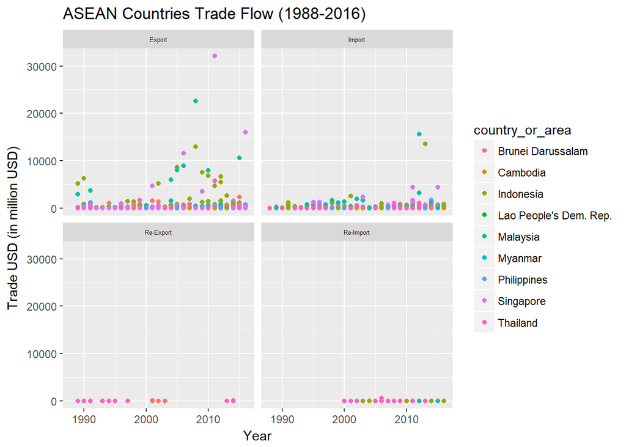

```r
  ggplot(asean.comm, aes(x=year, y=trade_usd/1000000, color=country_or_area))+
  geom_point()+
  facet_wrap(~as.factor(flow), ncol=2)+
  scale_size(range=c(1,30))+
  theme(legend.position = "right", strip.text=element_text(size=5))+
  labs(title="ASEAN Countries Trade Flow (1988-2016)", x="Year", y="Trade USD (in million USD)")
```

# Step 3: Summing trade_usd export and import per year for every country

Next, we sum the trade_usd of export and import per year for every country. So we can know how much USD they gain (by exporting) or lose (by importing) for each year.

```r
import.sum <- aggregate.data.frame(import$trade_usd, by = list(import$year, import$country_or_area), sum)
names(import.sum) <- c("Year", "Country", "Trade_USD_Import")

export.sum <- aggregate.data.frame(export$trade_usd, by = list(export$year, export$country_or_area), sum)
names(export.sum) <- c("Year", "Country", "Trade_USD_Export")

reimport.sum <- aggregate.data.frame(reimport$trade_usd, by = list(reimport$year, reimport$country_or_area), sum)
names(reimport.sum) <- c("Year", "Country", "Trade_USD_Re_Import")

reexport.sum <- aggregate.data.frame(reexport$trade_usd, by = list(reexport$year, reexport$country_or_area), sum)
names(reexport.sum) <- c("Year", "Country", "Trade_USD_Re_Export")
```

## Import

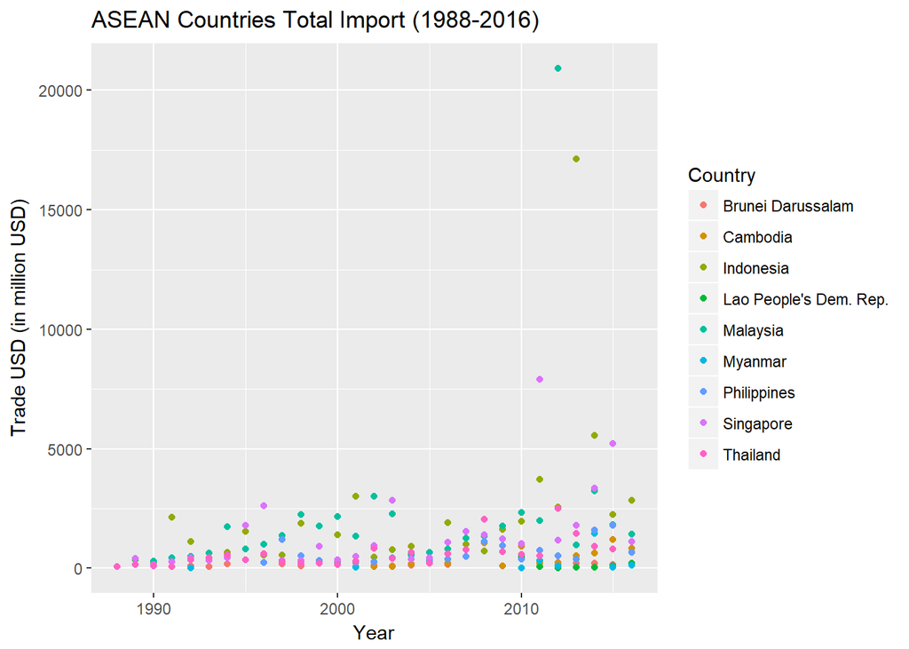

```r
ggplot(import.sum, aes(x=Year, y=Trade_USD_Import/1000000, color=Country))+
  geom_point()+
  labs(title="ASEAN Countries Total Import (1988-2016)", y="Trade USD (in million USD)")
```

## Export

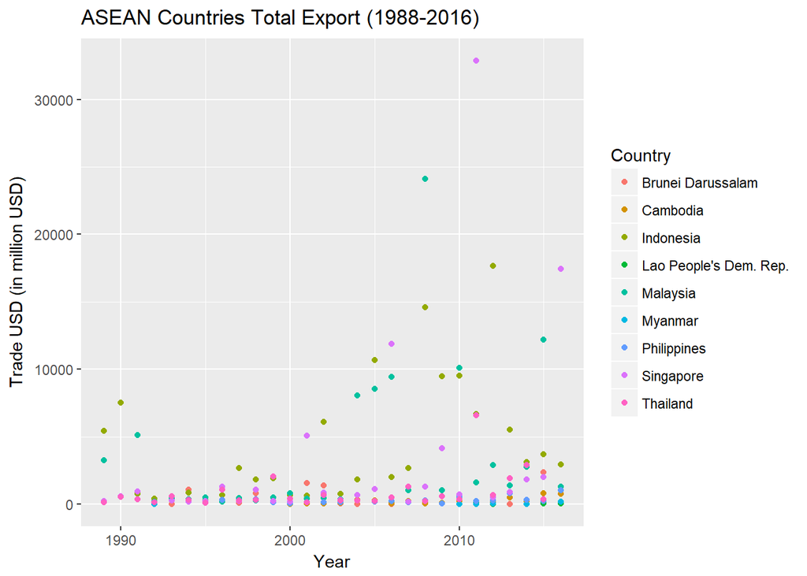

```r
ggplot(export.sum, aes(x=Year, y=Trade_USD_Export/1000000, color=Country))+
  geom_point()+
  labs(title="ASEAN Countries Total Export (1988-2016)", y="Trade USD (in million USD)")
```

## Re-Import

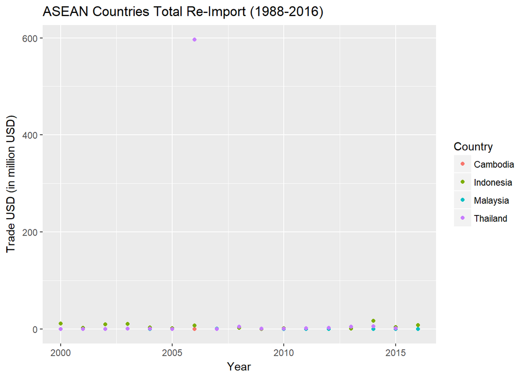

```r
ggplot(reimport.sum, aes(x=Year, y=Trade_USD_Re_Import/1000000, color=Country))+
  geom_point()+
  labs(title="ASEAN Countries Total Re-Import (1988-2016)", y="Trade USD (in million USD)")
```

## Re-Export

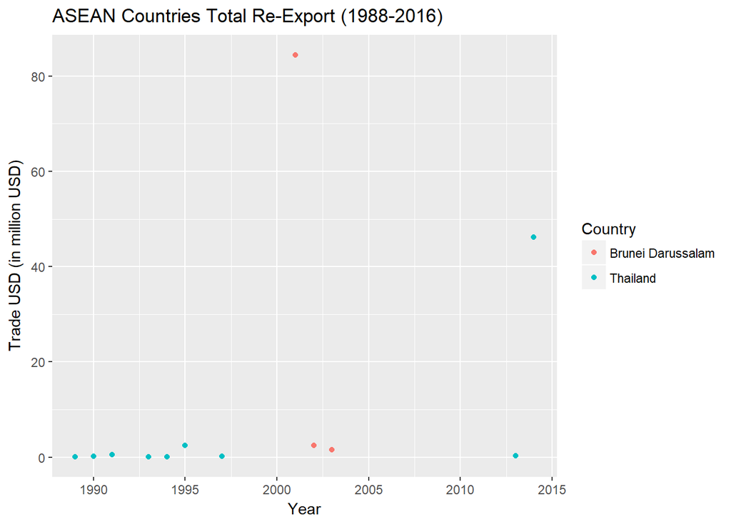

```r
ggplot(reexport.sum, aes(x=Year, y=Trade_USD_Re_Export/1000000, color=Country))+
  geom_point()+
  labs(title="ASEAN Countries Total Re-Export (1988-2016)", y="Trade USD (in million USD)")
```

# Step 4: Create a single data frame containing BOT

We have to join both of our data frames (from Step 2) so that we get a single data frame with column: Year, Country, Trade USD Import, Export, Re-Import, Re-Export, and BOT. BOT is calculated by subtracting sum of import and re-import from the sum of export and re-export.

```r
import.export.sum <- merge(import.sum, export.sum, by=c("Year", "Country"), all = TRUE)
reimport.reexport.sum <- merge(reimport.sum, reexport.sum, by=c("Year", "Country"), all = TRUE)
flow.sum <- merge(import.export.sum, reimport.reexport.sum, by=c("Year", "Country"), all = TRUE)

flow.sum[is.na(flow.sum)] <- 0
Balance_Of_Trade <- flow.sum$Trade_USD_Export+flow.sum$Trade_USD_Re_Export-flow.sum$Trade_USD_Import-flow.sum$Trade_USD_Re_Import
flow.sum <- cbind(flow.sum, Balance_Of_Trade)
```

# Step 5: Plotting the BOT

Before we plot the BOT, we have to find out the most extreme values of BOT (min and max). Both of the values will be useful to plot the annotation on the BOT plot.

```r
highest.balance <- max(flow.sum$Balance_Of_Trade)
lowest.balance <- min(flow.sum$Balance_Of_Trade)
extreme.balance <- c(highest.balance, lowest.balance)
```

This is the BOT plot.

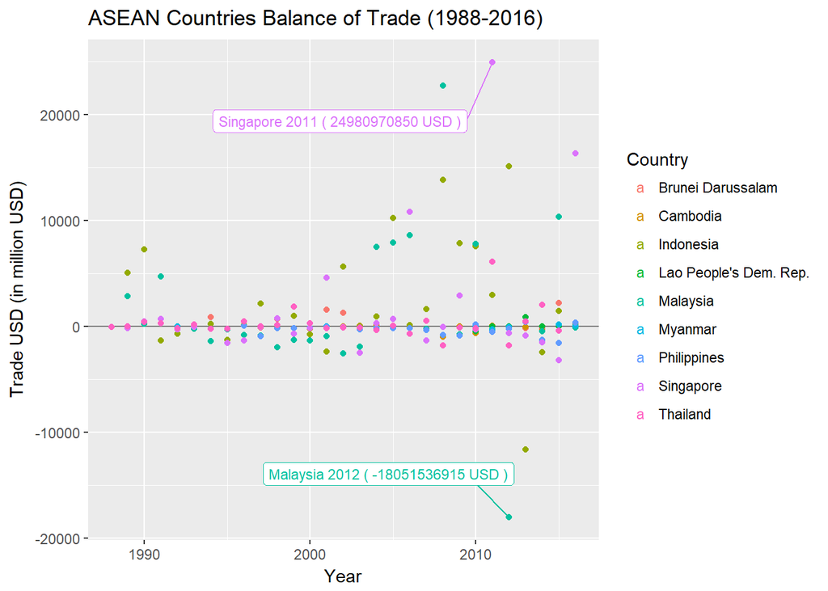

```r
ggplot(flow.sum, aes(x=Year, y=Balance_Of_Trade / 1000000, color=Country))+
  geom_hline(yintercept=0, alpha=0.5)+
  geom_point()+
  geom_label_repel(aes(label=ifelse(Balance_Of_Trade %in% extreme.balance, paste(Country, Year, "(", Balance_Of_Trade,"USD )"), "")), size=3, box.padding = 2)+
  labs(title="ASEAN Countries Balance of Trade (1988-2016)", y="Trade USD (in million USD)")
```

The BOT plot above shows that:  
* The highest BOT belongs to Singapore in 2011 with 24,980,970,850 USD  
* The lowest BOT belongs to Malaysia in 2012 with -18,051,536,915 USD

In addition, here we present the top 6 of the highest and lowest BOT.

## The Highest BOT

```r
temp1 <- flow.sum[order(flow.sum$Balance_Of_Trade, decreasing = T), ]
head(temp1)
```

```
##     Year   Country Trade_USD_Import Trade_USD_Export Trade_USD_Re_Import
## 136 2011 Singapore       7911747005      32892717855                   0
## 112 2008  Malaysia       1341285500      24115658247                   0
## 179 2016 Singapore       1116556607      17445936025                   0
## 140 2012 Indonesia       2564060309      17683728995              646230
## 111 2008 Indonesia        711555596      14587839411             2904122
## 102 2006 Singapore       1088211149      11900364542                   0
##     Trade_USD_Re_Export Balance_Of_Trade
## 136                   0      24980970850
## 112                   0      22774372747
## 179                   0      16329379418
## 140                   0      15119022456
## 111                   0      13873379693
## 102                   0      10812153393
```

## The Lowest BOT

```r
temp2 <- flow.sum[order(flow.sum$Balance_Of_Trade, decreasing = F), ]
head(temp2)
```

```
##     Year   Country Trade_USD_Import Trade_USD_Export Trade_USD_Re_Import
## 142 2012  Malaysia      20930062818       2878718604              192701
## 149 2013 Indonesia      17130781177       5515263971              834859
## 171 2015 Singapore       5217908946       1988293165                   0
## 73  2002  Malaysia       2996263232        456038324                   0
## 82  2003 Singapore       2845867828        327996563                   0
## 157 2014 Indonesia       5546479453       3136262437            17168794
##     Trade_USD_Re_Export Balance_Of_Trade
## 142                   0     -18051536915
## 149                   0     -11616352065
## 171                   0      -3229615781
## 73                    0      -2540224908
## 82                    0      -2517871265
## 157                   0      -2427385810
```

For the next step, we are interested to see why this happened.

# Step 6: Analyzing the Highest and Lowest BOT

In order to know the reason why they have the lowest and highest BOT, we need to see what commodities does Malaysia import in 2012 (lowest BOT) and what commodities does Singapore export in 2011 (highest BOT).

First, we create new data frame for Singapore’s export in 2011 and Malaysia’s import in 2012. Then, we get the top 6 for each data frame.

```r
export.sg2011 <- export[export$country_or_area == "Singapore" & export$year == 2011,]
import.my2012 <- import[import$country_or_area == "Malaysia" & import$year == 2012,]

top6export.sg2011 <- head(export.sg2011[order(export.sg2011$trade_usd, decreasing = T),])
top6import.my2012 <- head(import.my2012[order(import.my2012$trade_usd, decreasing = T),])
```

## Plotting the Top Exported/Imported Commodity

Plotting the Singapore’s export in 2011 by each top 6 exported commodity (by its trade_usd).

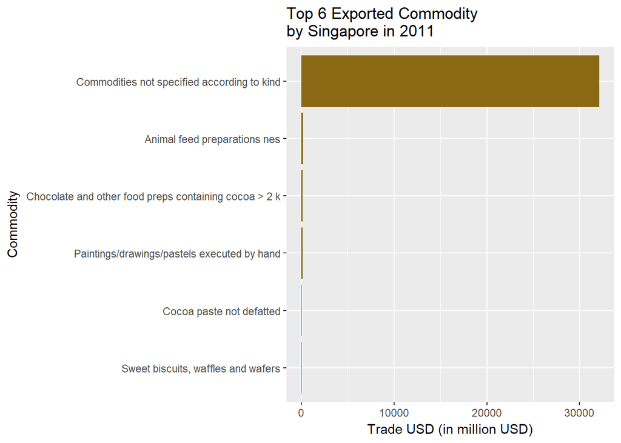

```r
ggplot(top6export.sg2011, aes(x=reorder(commodity, trade_usd), y=trade_usd/1000000))+
  geom_col(fill="goldenrod4")+
  coord_flip()+
  labs(title="Top 6 Exported Commodity\nby Singapore in 2011", x="Commodity", y="Trade USD (in million USD)")
```

But the most USD gain due to commodity export by Singapore in 2011 is an unspecified commodity. Therefore, we compare the next top 5.

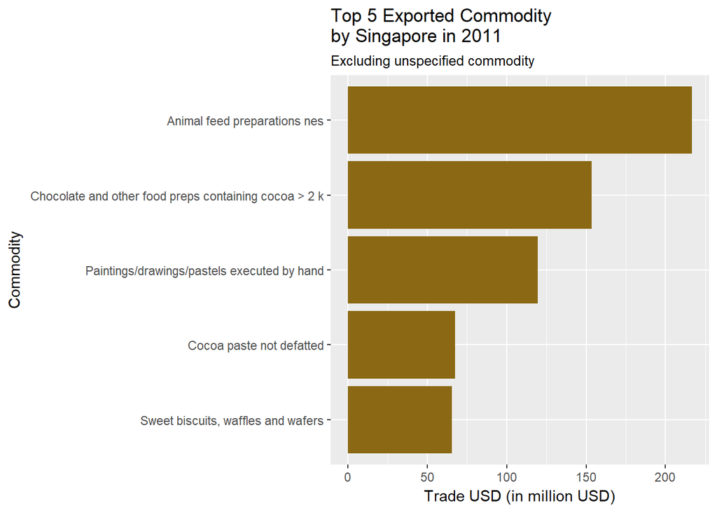

```r
ggplot(top6export.sg2011[-1,], aes(x=reorder(commodity, trade_usd), y=trade_usd/1000000))+
  geom_col(fill="goldenrod4")+
  coord_flip()+
  labs(title="Top 5 Exported Commodity\nby Singapore in 2011", subtitle="Excluding unspecified commodity", x="Commodity", y="Trade USD (in million USD)")
```

Next, plotting the Malaysia’s import in 2012 by top 6 imported commodity (by its trade_usd).

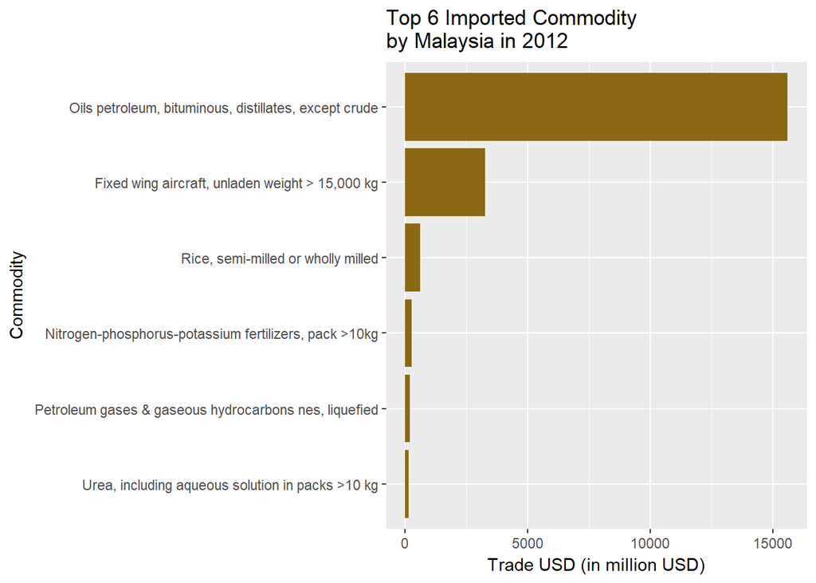

```r
ggplot(top6import.my2012, aes(x=reorder(commodity, trade_usd), y=trade_usd/1000000))+
  geom_col(fill="goldenrod4")+
  coord_flip()+
  labs(title="Top 6 Imported Commodity\nby Malaysia in 2012", x="Commodity", y="Trade USD (in million USD)")
```

# Result

From the plot above, we can easily know the reason why Malaysia in 2012 have the lowest balance (-18,051,536,915 USD) with total import 20,930,062,818 USD and the export only 2,878,718,604 USD. This happens due to the fact that Malaysia imported Oils petroleum commodity very much which makes up ~75% of Malaysia’s total import in 2012 at staggering 15,596,176,888 USD.

On the other hand, as for the highest balance, we don’t really know for sure from the most exported commodities plot (because of the unspecified commodity). But we know the second most exported is the animal feed preparation.

### No Pain No Gain

– Good bye and see you again –